# Stroke Survival Analysis - 1 Background

According to the Centers for Disease Control (CDC FastStats) in 2020, cardiovascular disease was the leading cause of death in the United States and cerebrovascular diseases (stroke) are ranked fifth (Figure 1).

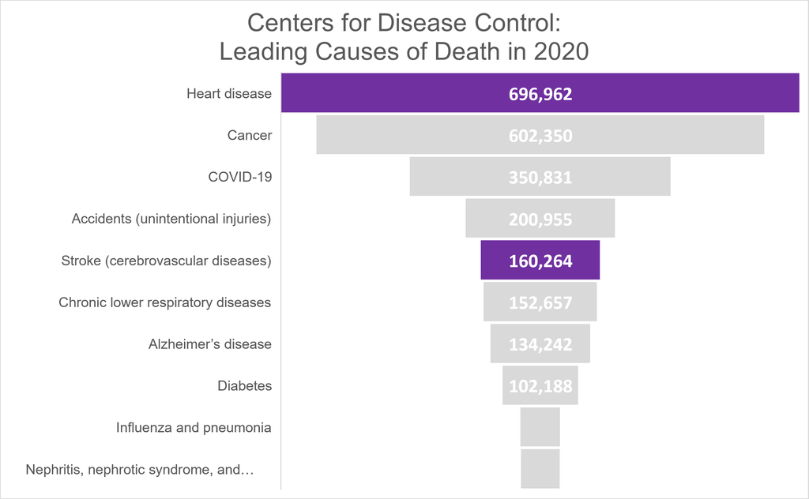

Figure 1

Oftentimes, Mississippi reports as having some of the highest, if not the highest, mortality rate when it comes to cardiovascular disease (CVD) (Keku et al., 2004), many attributable to African Americans (Sempos, Bild, & Manolio, 1999). In 1998 (Wyatt et al., 2003) and in response to the noted disparities, a collaboration between three higher education institutions and the National Institutes of Health, among other funders, established the Jackson Heart Study (JHS). The JHS is a “single-site, prospective, epidemiologic investigation of CVD among African Americans” (Keku et al., 2004). The area encompasses the tri county area surrounding Jackson, Mississippi. Participants were recruited using criteria outlined in Figure 2 from September 2000 - February 2004, with a final cohort size of 5,302.

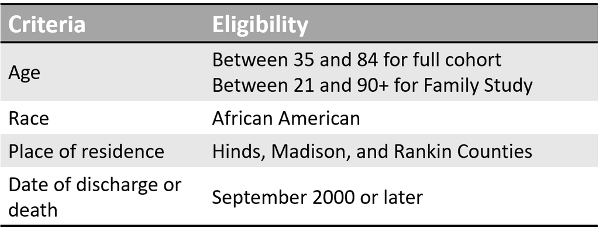

Figure 2

While heart disease has been identified as the leading cause of death, it’s also important to further explore other CVD, such as strokes. According to the CDC (CDC Stroke Home), 1 in 6 cardiovascular deaths was due to stroke, more than half of stroke survivors age 65+ have a reduction in mobility, and is a significant contributor to “serious long-term disability.” The National Institute of Neurological Disorders and Stroke (NINDS) (National Institute of Neurological Disorders and Stroke) defines a stroke of occurrence as “when the blood supply to part of the brain is suddenly interrupted or when a blood vessel in the brain bursts, spilling blood into the spaces surrounding brain cells.” As a result, brain cells are deprived of oxygen and nutrients. Strokes are further subcategorized into ischemic, which is the blockage of a blood vessel which brings blood to the brain, or hemorrhagic, when bleeding occurs in or around the brain.

There are several factors associated with stroke and are identified as: high, blood pressure, high cholesterol, previous stroke, heart disease, diabetes, obesity, sickle cell disease, family history, age, sex, race/ethnicity. In addition, there are several factors which contribute to stroke including a poor diet, minimal physical activity, excessive alcohol use and tobacco use (CDC Know Your Risk for Stroke). Of those, the CDC further drills down to identify high blood pressure, high cholesterol, smoking, obesity and diabetes as the major factors contributing to stroke (CDC Stroke Home). In addition, though age is not a major factor, risk increases with age.

The JHS, while not formally a surveillance data set, does possess two major attributes which lend itself towards the classification of surveillance data: annual followup (AFU) and medical record abstraction (MRA) (Keku et al., 2004). Trained interviewers conduct yearly calls to the cohort to inform annual followup data with a goal of capturing significant health events. These data are entered into the JHS data management system which interacts with MRA unit. In turn, the MRA unit identifies and extracts CVD data (illness and death) which flows to the North Carolina Collaborative Studies Coordinating Center (UNC-CSCC). The JHS Coordinating Center in Jackson, MS and the UNC-CSCC collaboratively manage the surveillance data.

A valuable part of any disease surveillance system is to analyze and interpret the data collected. Data can be used in a variety of ways including a suggestion of a hypothesis, to note trends, inform or evaluate prevention programs and to determine public health needs moving forward (Sullivan, McKenna, Waller, Williamson & Lee, 2010). The surveillance system’s purpose and design drive the type of analysis needed and has a broad range of methods that can be used. One method of analysis that considers the collection of data at multiple points in time or throughout the disease process is known as survival analysis, a statistical method to determine the time to an event of interest (Linden, Adams & Roberts, 2004). Survival analysis is frequently used in the medical field and events can be defined as disease recurrence, relapse-free time interval, remission or death. In the design of the analysis, it’s important to define and capture what the event is and the period of observation. Survival data rarely have a normal distribution with the majority of events early and tapering, leading to a skewed distribution making many modeling methods (like those assuming normal distribution) inaccurate (Clark, Bradburn, Love & Altman, 2003). Survival analysis has unique characteristics which should be defined:

- **Censoring** – only some individuals experience the event and can arise by:
  - Patient has not yet experienced the outcome by the end of the study
  - Patient is lost to follow-up during the study
  - Patient experiences an event that makes additional follow-up impossible
- **Right censoring** – The event occurs beyond the end of the follow-up time/study
- **Left censoring** – The event occurred prior to the first follow-up
- **Interval censoring** – The patients come in and out of observation
- **Noninformative censoring** – When a patient is lost from follow-up, they are just as likely to have a subsequent event as the remaining study participants
- **Informative censoring** – Patients withdraw from the study because of a decline in clinical condition or drug toxicity

Survival analysis looks at two related probability functions referred to as survivor, $S(t)$, the likelihood having not occurred at a specific time, and hazard, $h(t)$ or $\lambda(t)$, the likelihood of the event occurring at a specific time, which are related probabilities. The three most common methods include: Kaplan-Meier (KM) plots, Logrank tests, which are univariate (only take into account the factor of interest) and Cox proportional hazards model, which is a semi-parametric approach and the most common model used in multivariate survival analysis. Other multivariate analyses are available which take into account multiple variables/factors that might influence the outcome and include two general types of testing groups: proportional hazard approaches (semi-parametric & fully parametric approaches) and accelerated failure time models (Bradburn, Clark, Love & Altman, 2003).

The KM method is a straightforward model that requires no further explanation of variations in survival time in relation to independent variables (Linden, Adams & Roberts, 2004). Using this method is based on the assumption that all events occur independently of each other (Clark, Bradburn, Love & Altman, 2003). This model returns an estimation for each patient surviving at the start of the observation period as a probability of surviving to the end of each observation period. Each probability is a “step function” whose value changes only at each event time. A cumulative survival probability can be calculated by multiplying the probabilities of surviving from one interval to the next. The Logrank test compares the survival of two groups as is seen when using a control group. This method assumes no differences between groups and calculates the expected number of events at any given time for both groups.

The Cox Proportional Hazards (PH) regression model is the most used method to analyze survival data. One reason for its popularity as a model is its close resemblance to other regression models, which explains a dependent (outcome) variable is related to one or more independent variables (Linden, Adams & Roberts, 2004). This method “describes the relation between the event incident, as expressed by the hazard function and a set of covariates” and no one type of statistical distribution is assumed (Clark, Bradburn, Love & Altman, 2003). The regression is the logarithm of the hazard on the variables and maintains a key assumption that in any group, the hazard of that group is a constant multiple of the hazard in any other group. This method allows for the ability to control for censored cases and their effects, where as linear models aren’t capable of controlling censored cases.

In the JHS study, strokes can be documented in three ways - adjudicated cases, through the annual followup phone interviews and subsequent data or through data collected on forms at formal clinical visits. The focus of this analysis is to focus on adjudicated cases, as defined by the process by which trained medical personnel review the events of the study to confirm and classify the presence and the type of stroke (Longstreth, Gasca, Gottesman, Pearce & Sacco, 2018).